# Analyse en Composantes Multiples (ACM)

Fadli Aaron

2025-12-10

# 1. Introduction

Cette analyse en composantes multiples (ACM) étudie l’offre de soins en France de 2010 à 2024 à travers trois dimensions : l’effectif des professionnels de santé, leur densité territoriale, et le niveau d’équipement sanitaire.

## Chargement et préparation des données

```r
# Charger la base ACM
base_acm <- readRDS("../datafinal/base_acm.rds")

# Vérifier la structure
str(base_acm)
```

```
## tibble [50,806 × 6] (S3: tbl_df/tbl/data.frame)
##  $ annee           : num [1:50806] 2010 2010 2010 2010 2010 2010 2010 2010 2010 2010 ...
##  $ profession_sante: chr [1:50806] "anesthesistes reanimateurs" "autres medecins" "cardiologues" "chirurgiens" ...
##  $ departement     : chr [1:50806] "01" "01" "01" "01" ...
##  $ classe_effectif : Factor w/ 4 levels "Très faible",..: 2 1 2 2 4 2 2 1 4 4 ...
##  $ classe_densite  : Factor w/ 5 levels "Désert","Sous-doté",..: 2 1 2 2 4 2 2 1 4 4 ...
##  $ classe_equip    : Factor w/ 4 levels "Peu équipé","Moyennement équipé",..: 2 2 2 2 2 2 2 2 2 2 ...
```

```r
# Distribution des modalités
base_acm %>%
  select(classe_effectif:classe_equip) %>%
  summary()
```

```
##     classe_effectif        classe_densite              classe_equip
##  Très faible:13507   Désert       :12565   Peu équipé        :17067
##  Faible     :11864   Sous-doté    :12795   Moyennement équipé:17278
##  Moyen      :12637   Correct      :12741   Très équipé       :16461
##  Élevé      :12798   Bien doté    :12705   Non renseigné     :    0
##                      Non renseigné:    0
```

# 2. Réalisation de l’ACM

```r
# ACM avec les 3 premières colonnes en supplémentaires
# Colonnes 1-3 : annee, profession_sante, departement (supplémentaires)
# Colonnes 4-6 : classe_effectif, classe_densite, classe_equip (ACTIVES)

res_mca <- MCA(
  base_acm,
  quali.sup = 1:3,
  graph = FALSE
)
```

# 3. Valeurs propres et inertie

## Éboulis des valeurs propres

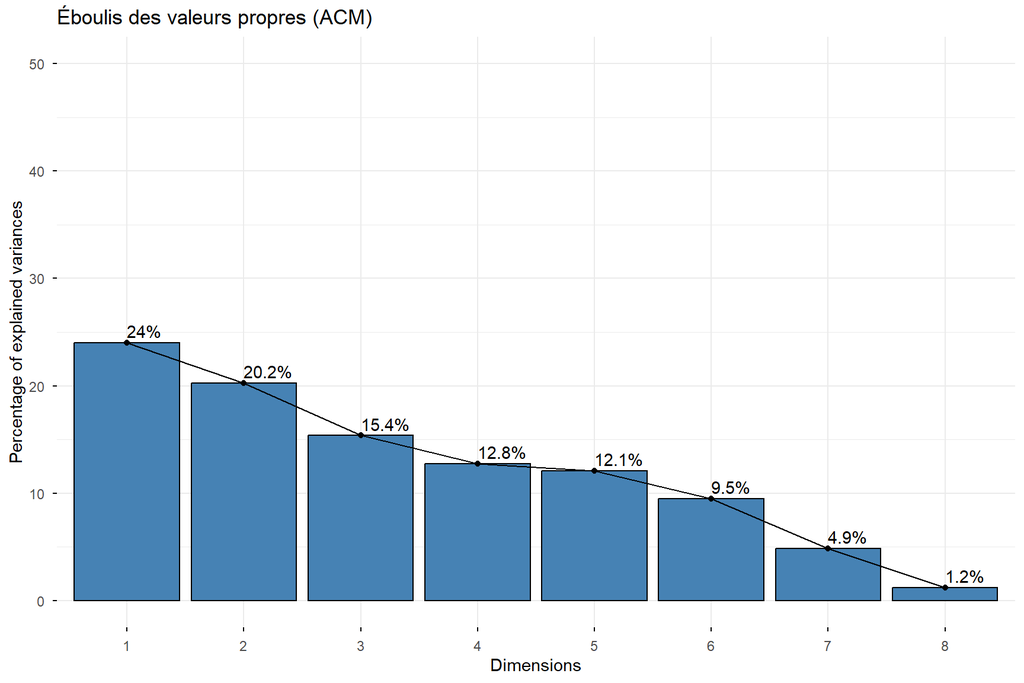

```r
fviz_screeplot(
  res_mca,
  addlabels = TRUE,
  barfill = "steelblue",
  barcolor = "black",
  ylim = c(0, 50),
  title = "Éboulis des valeurs propres (ACM)"
)
```

**Interprétation** : Les deux premières dimensions capturent respectivement 24% et 20.2% de l’inertie totale, soit 44.2% cumulées.

## Tableau récapitulatif

```r
# Créer un tableau des valeurs propres
eig_table <- as.data.frame(res_mca$eig) %>%
  rownames_to_column("Dimension") %>%
  mutate(Dimension = paste0("Dim ", Dimension)) %>%
  head(8) %>%
  select(
    Dimension,
    `Valeur propre` = eigenvalue,
    `% variance` = `percentage of variance`,
    `% cumulé` = `cumulative percentage of variance`
  ) %>%
  mutate(across(where(is.numeric), ~round(., 2)))

knitr::kable(
  eig_table,
  caption = "Tableau 1 : Valeurs propres et pourcentages de variance expliquée",
  align = "lrrr"
)
```

Tableau 1 : Valeurs propres et pourcentages de variance expliquée

| Dimension | Valeur propre | % variance | % cumulé |
| --- | --- | --- | --- |
| Dim dim 1 | 0.64 | 24.01 | 24.01 |
| Dim dim 2 | 0.54 | 20.24 | 44.24 |
| Dim dim 3 | 0.41 | 15.37 | 59.61 |
| Dim dim 4 | 0.34 | 12.77 | 72.38 |
| Dim dim 5 | 0.32 | 12.06 | 84.44 |
| Dim dim 6 | 0.25 | 9.51 | 93.95 |
| Dim dim 7 | 0.13 | 4.86 | 98.81 |
| Dim dim 8 | 0.03 | 1.19 | 100.00 |

**Interprétation** : Les deux premières dimensions capturent 44.2% de l’inertie totale, ce qui est satisfaisant pour une ACM avec 3 variables actives ayant 11 modalités au total.

# 4. Contributions des variables

## Contributions à la Dimension 1

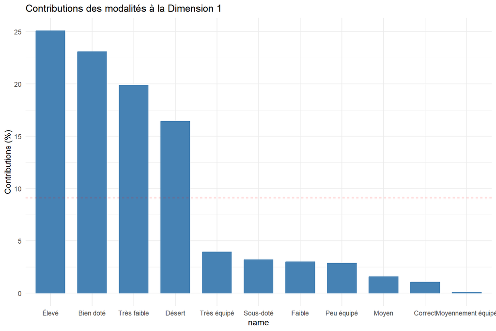

```r
fviz_contrib(
  res_mca,
  choice = "var",
  axes = 1,
  top = 15,
  fill = "steelblue"
) +
  ggtitle("Contributions des modalités à la Dimension 1") +
  theme_minimal()
```

**Interprétation** : L’axe 1 est dominé par les modalités “Élevé”, “Bien doté” et “Très faible”, “Désert” → **gradient de dotation médicale**.

## Contributions à la Dimension 2

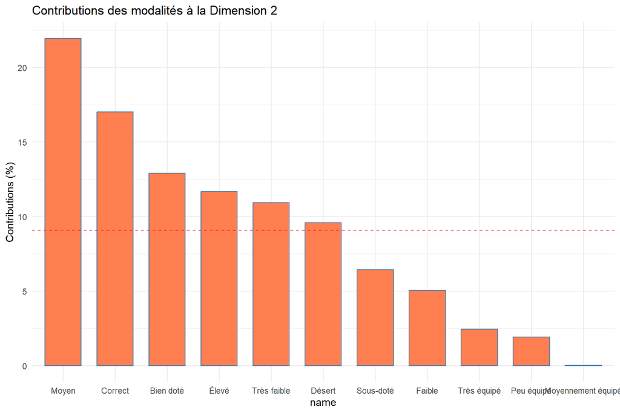

```r
fviz_contrib(
  res_mca,
  choice = "var",
  axes = 2,
  top = 15,
  fill = "coral"
) +
  ggtitle("Contributions des modalités à la Dimension 2") +
  theme_minimal()
```

**Interprétation** : L’axe 2 est dominé par “Moyen”, “Correct” et “Bien doté” → **gradient de normalité** (situations moyennes vs extrêmes).

# 5. Représentation des modalités

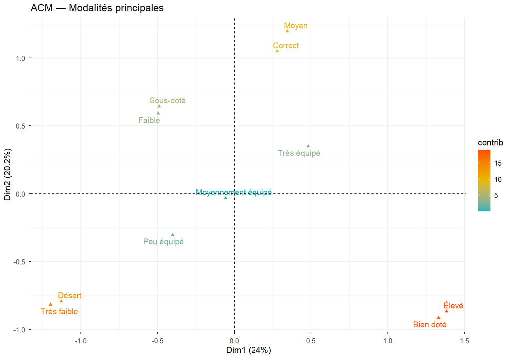

```r
fviz_mca_var(
  res_mca,
  col.var = "contrib",
  gradient.cols = c("#00AFBB", "#E7B800", "#FC4E07"),
  repel = TRUE,
  select.var = list(contrib = 15),
  ggtheme = theme_minimal(),
  title = "ACM — Modalités principales",
  labelsize = 4
) +
  theme(text = element_text(size = 12))
```

**Interprétation** :

- **Axe horizontal (Dim1)** : Opposition déserts médicaux (gauche) vs territoires bien dotés (droite)
- **Axe vertical (Dim2)** : Opposition situations moyennes/équilibrées (haut) vs situations extrêmes (bas)

# 6. Représentation des individus

## Vue d’ensemble du nuage d’individus

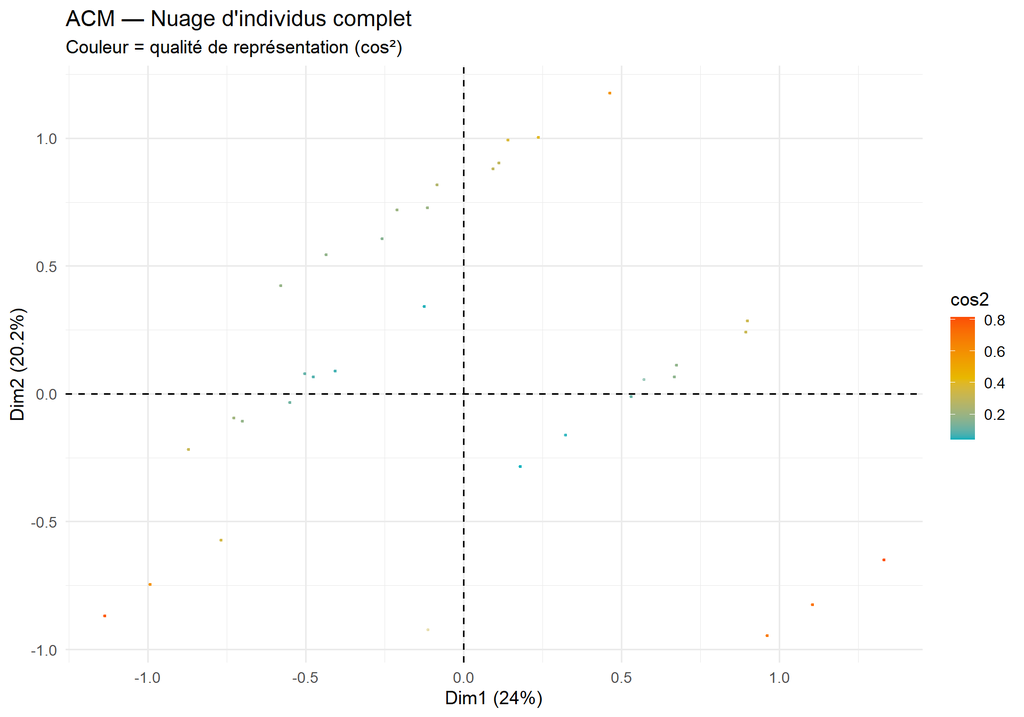

```r
fviz_mca_ind(
  res_mca,
  alpha.ind = 0.15,
  pointsize = 0.5,
  geom = "point",
  col.ind = "cos2",
  gradient.cols = c("#00AFBB", "#E7B800", "#FC4E07"),
  title = "ACM — Nuage d'individus complet",
  subtitle = "Couleur = qualité de représentation (cos²)"
) +
  theme_minimal(base_size = 13)
```

## Échantillon avec meilleure visibilité

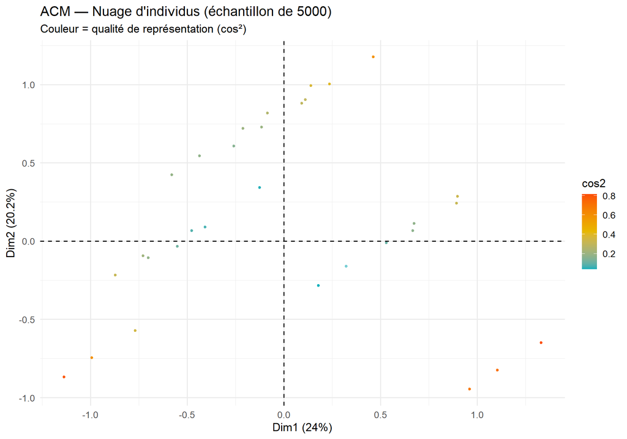

```r
set.seed(123)
sample_size <- 5000

fviz_mca_ind(
  res_mca,
  select.ind = list(name = sample(1:nrow(base_acm), sample_size)),
  geom = "point",
  alpha.ind = 0.3,
  pointsize = 1,
  col.ind = "cos2",
  gradient.cols = c("#00AFBB", "#E7B800", "#FC4E07"),
  title = "ACM — Nuage d'individus (échantillon de 5000)",
  subtitle = "Couleur = qualité de représentation (cos²)"
) +
  theme_minimal(base_size = 13)
```

## Carte de densité

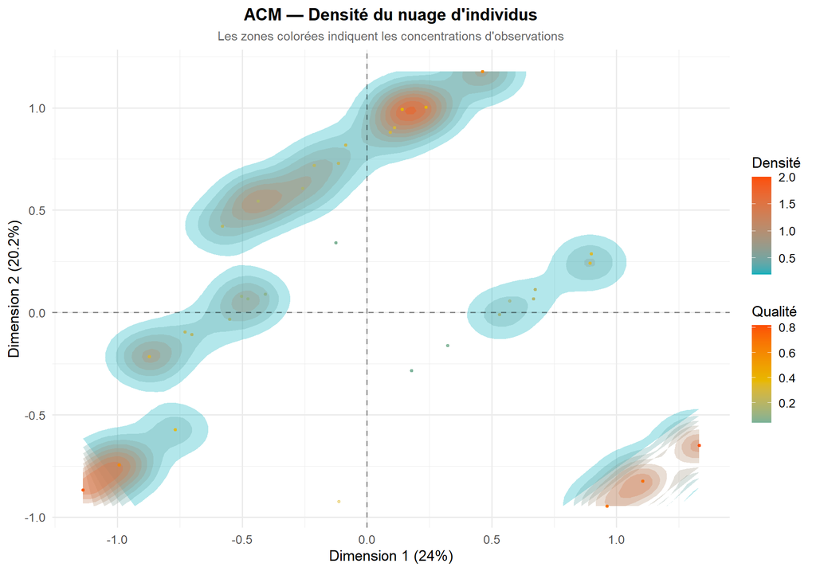

```r
# Récupérer les coordonnées
ind_coords <- as.data.frame(res_mca$ind$coord[, 1:2])
ind_coords$cos2 <- res_mca$ind$cos2[, 1] + res_mca$ind$cos2[, 2]

# Graphique avec densité
ggplot(ind_coords, aes(x = `Dim 1`, y = `Dim 2`)) +
  # Contours de densité
  stat_density_2d(aes(fill = after_stat(level)),
                  geom = "polygon", alpha = 0.3) +
  scale_fill_gradient(low = "#00AFBB", high = "#FC4E07") +
  # Points par-dessus
  geom_point(aes(color = cos2), alpha = 0.2, size = 0.8) +
  scale_color_gradient2(low = "#00AFBB", mid = "#E7B800", high = "#FC4E07",
                        midpoint = median(ind_coords$cos2)) +
  # Axes
  geom_hline(yintercept = 0, linetype = "dashed", alpha = 0.4) +
  geom_vline(xintercept = 0, linetype = "dashed", alpha = 0.4) +
  # Labels
  labs(
    title = "ACM — Densité du nuage d'individus",
    subtitle = "Les zones colorées indiquent les concentrations d'observations",
    x = paste0("Dimension 1 (", round(res_mca$eig[1, 2], 1), "%)"),
    y = paste0("Dimension 2 (", round(res_mca$eig[2, 2], 1), "%)"),
    fill = "Densité",
    color = "Qualité"
  ) +
  theme_minimal(base_size = 13) +
  theme(
    plot.title = element_text(face = "bold", size = 15, hjust = 0.5),
    plot.subtitle = element_text(size = 11, hjust = 0.5, color = "grey40")
  )
```

# 7. Classification : Identification des profils

## Clustering k-means (k=4)

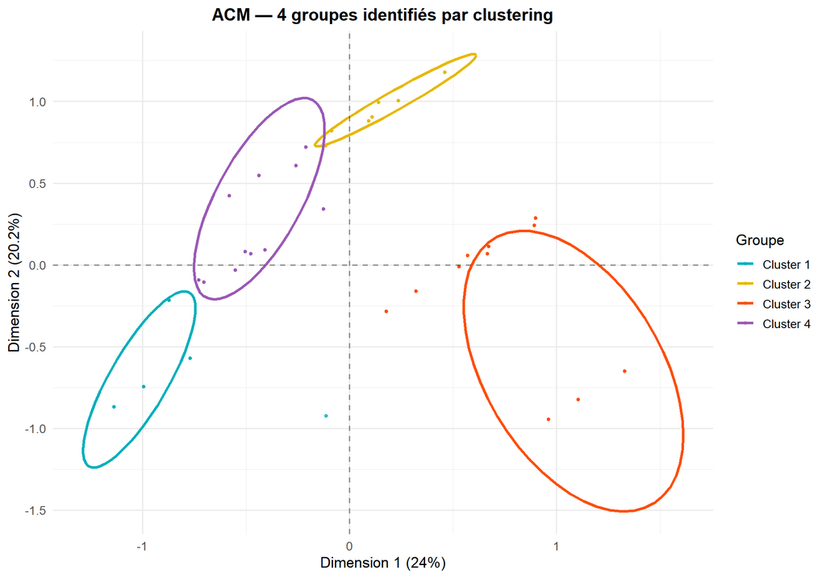

```r
# Clustering sur les coordonnées ACM
set.seed(123)
coords <- res_mca$ind$coord[, 1:2]

# K-means avec 4 clusters
kmeans_result <- kmeans(coords, centers = 4, nstart = 25)

# Ajouter les clusters aux coordonnées
ind_coords$cluster <- factor(kmeans_result$cluster)

# Graphique
ggplot(ind_coords, aes(x = `Dim 1`, y = `Dim 2`, color = cluster)) +
  geom_point(alpha = 0.5, size = 1) +
  stat_ellipse(level = 0.95, linewidth = 1.2) +
  scale_color_manual(
    values = c("#00AFBB", "#E7B800", "#FC4E07", "#9B59B6"),
    labels = c("Cluster 1", "Cluster 2", "Cluster 3", "Cluster 4")
  ) +
  geom_hline(yintercept = 0, linetype = "dashed", alpha = 0.4) +
  geom_vline(xintercept = 0, linetype = "dashed", alpha = 0.4) +
  labs(
    title = "ACM — 4 groupes identifiés par clustering",
    x = paste0("Dimension 1 (", round(res_mca$eig[1, 2], 1), "%)"),
    y = paste0("Dimension 2 (", round(res_mca$eig[2, 2], 1), "%)"),
    color = "Groupe"
  ) +
  theme_minimal(base_size = 13) +
  theme(
    plot.title = element_text(face = "bold", size = 15, hjust = 0.5)
  )
```

## Description des clusters

```r
# Ajouter les clusters à la base
base_acm_clust <- base_acm %>%
  mutate(cluster = factor(kmeans_result$cluster))

# Distribution des modalités par cluster
cluster_summary <- base_acm_clust %>%
  group_by(cluster) %>%
  summarise(
    n = n(),
    pct = round(n() / nrow(base_acm_clust) * 100, 1),
    effectif_dom = names(sort(table(classe_effectif), decreasing = TRUE))[1],
    densite_dom = names(sort(table(classe_densite), decreasing = TRUE))[1],
    equip_dom = names(sort(table(classe_equip), decreasing = TRUE))[1]
  )

knitr::kable(
  cluster_summary,
  caption = "Tableau 2 : Caractérisation des 4 clusters",
  col.names = c("Cluster", "Effectif", "%", "Effectif dominant",
                "Densité dominante", "Équipement dominant")
)
```

Tableau 2 : Caractérisation des 4 clusters

| Cluster | Effectif | % | Effectif dominant | Densité dominante | Équipement dominant |
| --- | --- | --- | --- | --- | --- |
| 1 | 12497 | 24.6 | Très faible | Désert | Peu équipé |
| 2 | 11699 | 23.0 | Moyen | Correct | Très équipé |
| 3 | 14671 | 28.9 | Élevé | Bien doté | Très équipé |
| 4 | 11939 | 23.5 | Faible | Sous-doté | Moyennement équipé |

## Profils détaillés

```r
# Cluster 1
cat("### Cluster 1 - Profil\n")
```

```
## ### Cluster 1 - Profil
```

```r
base_acm_clust %>%
  filter(cluster == 1) %>%
  select(classe_effectif:classe_equip) %>%
  summary()
```

```
##     classe_effectif        classe_densite             classe_equip
##  Très faible:12497   Désert       :9624   Peu équipé        :7050
##  Faible     :    0   Sous-doté    :2871   Moyennement équipé:4035
##  Moyen      :    0   Correct      :   0   Très équipé       :1412
##  Élevé      :    0   Bien doté    :   2   Non renseigné     :   0
##                      Non renseigné:   0
```

```r
# Cluster 2
cat("\n### Cluster 2 - Profil\n")
```

```
##
## ### Cluster 2 - Profil
```

```r
base_acm_clust %>%
  filter(cluster == 2) %>%
  select(classe_effectif:classe_equip) %>%
  summary()
```

```
##     classe_effectif        classe_densite             classe_equip
##  Très faible:    0   Désert       :   0   Peu équipé        :1507
##  Faible     :  908   Sous-doté    :3513   Moyennement équipé:4319
##  Moyen      :10791   Correct      :8186   Très équipé       :5873
##  Élevé      :    0   Bien doté    :   0   Non renseigné     :   0
##                      Non renseigné:   0
```

```r
# Cluster 3
cat("\n### Cluster 3 - Profil\n")
```

```
##
## ### Cluster 3 - Profil
```

```r
base_acm_clust %>%
  filter(cluster == 3) %>%
  select(classe_effectif:classe_equip) %>%
  summary()
```

```
##     classe_effectif        classe_densite              classe_equip
##  Très faible:    0   Désert       :    0   Peu équipé        :4274
##  Faible     :  142   Sous-doté    :    4   Moyennement équipé:4579
##  Moyen      : 1731   Correct      : 1964   Très équipé       :5818
##  Élevé      :12798   Bien doté    :12703   Non renseigné     :   0
##                      Non renseigné:    0
```

```r
# Cluster 4
cat("\n### Cluster 4 - Profil\n")
```

```
##
## ### Cluster 4 - Profil
```

```r
base_acm_clust %>%
  filter(cluster == 4) %>%
  select(classe_effectif:classe_equip) %>%
  summary()
```

```
##     classe_effectif        classe_densite             classe_equip
##  Très faible: 1010   Désert       :2941   Peu équipé        :4236
##  Faible     :10814   Sous-doté    :6407   Moyennement équipé:4345
##  Moyen      :  115   Correct      :2591   Très équipé       :3358
##  Élevé      :    0   Bien doté    :   0   Non renseigné     :   0
##                      Non renseigné:   0
```

**Interprétation des clusters** :

- **Cluster 1** : Déserts médicaux sévères (effectifs très faibles, désert médical, peu équipé)
- **Cluster 2** : Situations moyennes équilibrées (effectifs moyens, densité correcte)
- **Cluster 3** : Métropoles sur-dotées (effectifs élevés, bien doté, très équipé)
- **Cluster 4** : Situations intermédiaires (profil mixte, territoires en transition)

# 8. Biplot : Synthèse visuelle

## Biplot classique

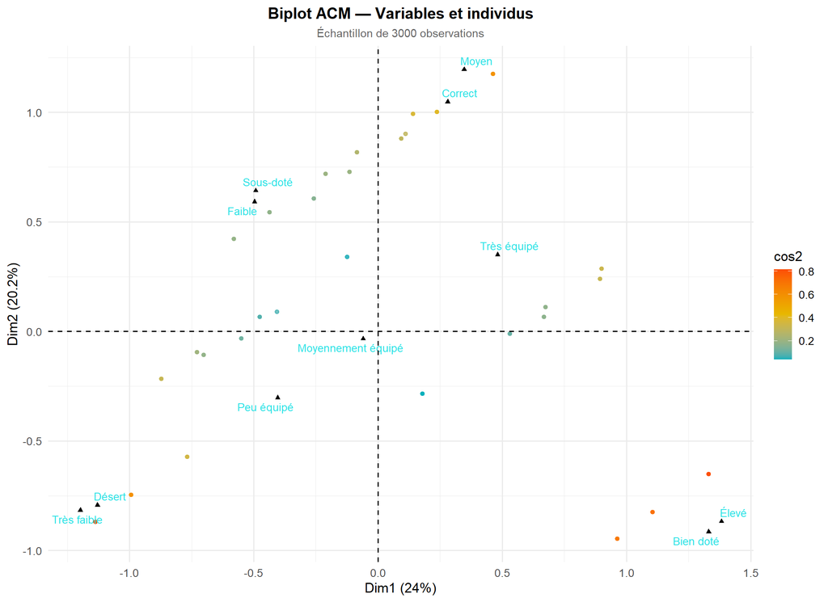

```r
# Échantillonner pour plus de clarté
set.seed(123)
sample_ids <- sample(1:nrow(base_acm), 3000)

fviz_mca_biplot(
  res_mca,
  select.ind = list(name = sample_ids),
  label = "var",
  geom.ind = "point",
  col.ind = "cos2",
  gradient.cols = c("#00AFBB", "#E7B800", "#FC4E07"),
  alpha.ind = 0.3,
  pointsize.ind = 1,
  col.var = "black",
  labelsize = 4.5,
  repel = TRUE,
  invisible = "quali.sup",
  title = "Biplot ACM — Variables et individus",
  subtitle = "Échantillon de 3000 observations"
) +
  theme_minimal(base_size = 13) +
  theme(
    plot.title = element_text(face = "bold", size = 15, hjust = 0.5),
    plot.subtitle = element_text(size = 11, hjust = 0.5, color = "grey40")
  )
```

## Biplot avec clusters

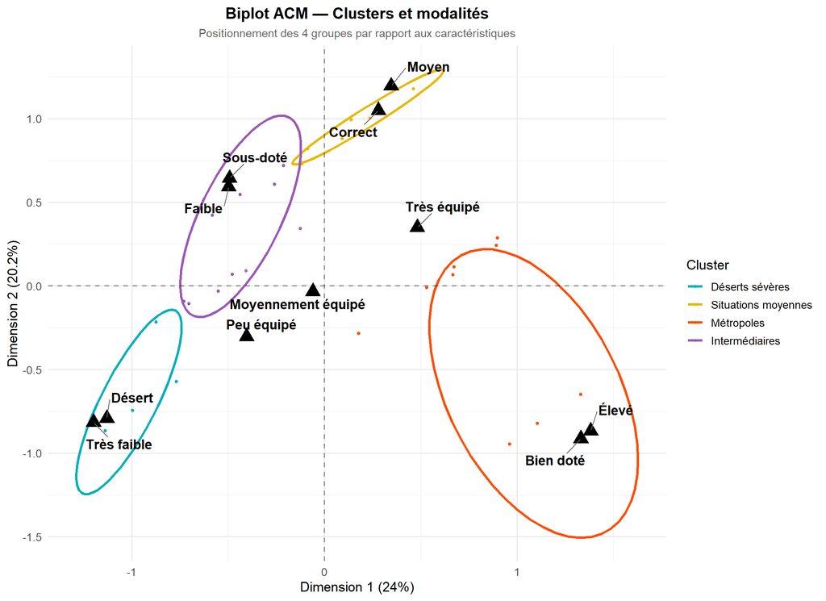

```r
# Échantillonner avec clusters
set.seed(123)
sample_ids <- sample(1:nrow(base_acm), 3000)
ind_sample <- as.data.frame(res_mca$ind$coord[sample_ids, 1:2])
ind_sample$cluster <- factor(kmeans_result$cluster[sample_ids])

# Modalités actives uniquement (11 premières)
var_coords <- as.data.frame(res_mca$var$coord[1:11, 1:2])
var_coords$label <- rownames(var_coords)

# Biplot clusters + modalités
ggplot() +
  # Individus par cluster
  geom_point(
    data = ind_sample,
    aes(x = `Dim 1`, y = `Dim 2`, color = cluster),
    alpha = 0.3,
    size = 1
  ) +
  # Ellipses
  stat_ellipse(
    data = ind_sample,
    aes(x = `Dim 1`, y = `Dim 2`, color = cluster),
    level = 0.95,
    linewidth = 1.2
  ) +
  scale_color_manual(
    values = c("#00AFBB", "#E7B800", "#FC4E07", "#9B59B6"),
    labels = c("Déserts sévères", "Situations moyennes",
               "Métropoles", "Intermédiaires"),
    name = "Cluster"
  ) +
  # Modalités actives
  geom_point(
    data = var_coords,
    aes(x = `Dim 1`, y = `Dim 2`),
    color = "black",
    size = 5,
    shape = 17
  ) +
  geom_text_repel(
    data = var_coords,
    aes(x = `Dim 1`, y = `Dim 2`, label = label),
    size = 4.5,
    fontface = "bold",
    box.padding = 1,
    max.overlaps = 20,
    segment.color = "grey40"
  ) +
  # Axes
  geom_hline(yintercept = 0, linetype = "dashed", alpha = 0.4) +
  geom_vline(xintercept = 0, linetype = "dashed", alpha = 0.4) +
  # Labels
  labs(
    title = "Biplot ACM — Clusters et modalités",
    subtitle = "Positionnement des 4 groupes par rapport aux caractéristiques",
    x = paste0("Dimension 1 (", round(res_mca$eig[1, 2], 1), "%)"),
    y = paste0("Dimension 2 (", round(res_mca$eig[2, 2], 1), "%)")
  ) +
  theme_minimal(base_size = 13) +
  theme(
    plot.title = element_text(face = "bold", size = 15, hjust = 0.5),
    plot.subtitle = element_text(size = 11, hjust = 0.5, color = "grey40"),
    legend.position = "right"
  )
```

# 9. Analyse des départements

## Départements extrêmes

```r
# Coordonnées moyennes par département
ind_coords_dept <- as.data.frame(res_mca$ind$coord[, 1:2])
ind_coords_dept$departement <- base_acm$departement

dept_coords <- ind_coords_dept %>%
  group_by(departement) %>%
  summarise(
    Dim1 = mean(`Dim 1`),
    Dim2 = mean(`Dim 2`),
    n_obs = n()
  ) %>%
  arrange(desc(Dim1))

# Top 10 mieux dotés
cat("### Top 10 des départements les mieux dotés\n")
```

```
## ### Top 10 des départements les mieux dotés
```

```r
knitr::kable(
  dept_coords %>% head(10),
  caption = "Départements les mieux dotés en professionnels de santé",
  digits = 2
)
```

Départements les mieux dotés en professionnels de santé

| departement | Dim1 | Dim2 | n_obs |
| --- | --- | --- | --- |
| 75 | 0.70 | 0.11 | 553 |
| 13 | 0.61 | 0.23 | 554 |
| 69 | 0.58 | 0.26 | 552 |
| 31 | 0.52 | 0.34 | 553 |
| 34 | 0.50 | 0.34 | 553 |
| 06 | 0.49 | 0.36 | 554 |
| 33 | 0.49 | 0.23 | 553 |
| 92 | 0.49 | 0.31 | 553 |
| 59 | 0.49 | 0.17 | 552 |
| 44 | 0.43 | 0.29 | 537 |

```r
# Top 10 déserts médicaux
cat("\n### Top 10 des déserts médicaux\n")
```

```
##
## ### Top 10 des déserts médicaux
```

```r
knitr::kable(
  dept_coords %>% tail(10) %>% arrange(Dim1),
  caption = "Départements en situation de désert médical",
  digits = 2
)
```

Départements en situation de désert médical

| departement | Dim1 | Dim2 | n_obs |
| --- | --- | --- | --- |
| 36 | -0.51 | -0.34 | 523 |
| 15 | -0.45 | -0.31 | 528 |
| 52 | -0.42 | -0.22 | 495 |
| 08 | -0.41 | -0.30 | 532 |
| 23 | -0.41 | -0.23 | 403 |
| 70 | -0.40 | -0.30 | 473 |
| 48 | -0.40 | -0.25 | 422 |
| 53 | -0.40 | -0.21 | 509 |
| 58 | -0.39 | -0.25 | 522 |
| 61 | -0.38 | -0.23 | 477 |

## Cartographie des départements

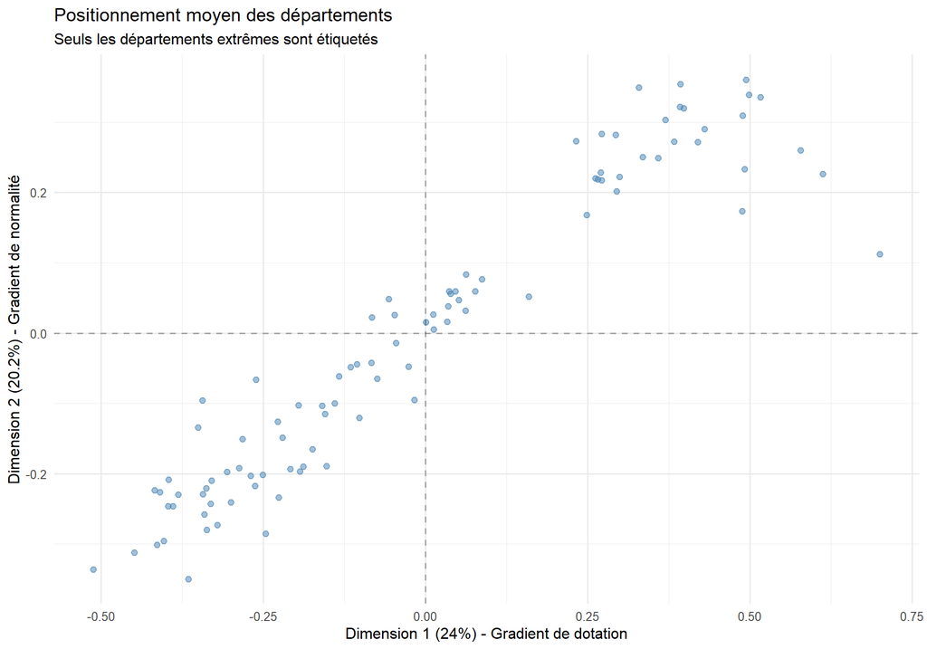

```r
# Identifier les départements extrêmes
dept_extremes <- dept_coords %>%
  filter(abs(Dim1) > 0.8 | abs(Dim2) > 0.8)

# Graphique
ggplot(dept_coords, aes(x = Dim1, y = Dim2)) +
  geom_point(alpha = 0.5, size = 2, color = "steelblue") +
  geom_text_repel(
    data = dept_extremes,
    aes(label = departement),
    size = 3.5,
    fontface = "bold",
    box.padding = 0.5,
    max.overlaps = 20
  ) +
  geom_hline(yintercept = 0, linetype = "dashed", alpha = 0.3) +
  geom_vline(xintercept = 0, linetype = "dashed", alpha = 0.3) +
  labs(
    title = "Positionnement moyen des départements",
    subtitle = "Seuls les départements extrêmes sont étiquetés",
    x = "Dimension 1 (24%) - Gradient de dotation",
    y = "Dimension 2 (20.2%) - Gradient de normalité"
  ) +
  theme_minimal(base_size = 12)
```

# 10. Analyse régionale

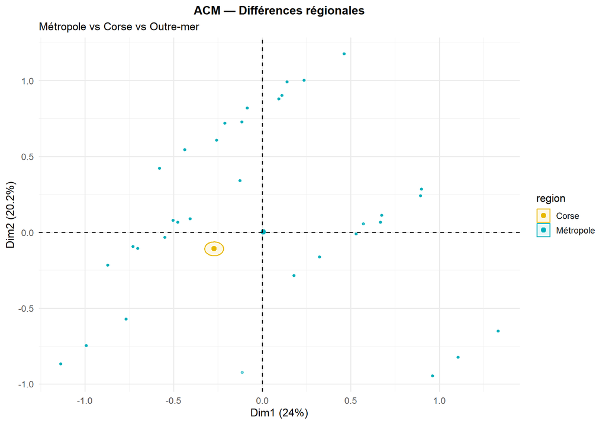

```r
# Créer variable région
base_acm_region <- base_acm %>%
  mutate(
    region = case_when(
      departement %in% c("2A", "2B") ~ "Corse",
      departement %in% c("971", "972", "973", "974", "976") ~ "Outre-mer",
      TRUE ~ "Métropole"
    )
  )

# ACM avec région en supplémentaire
res_mca_region <- MCA(
  base_acm_region,
  quali.sup = c(1, 2, 3, 7),
  graph = FALSE
)

# Graphique
fviz_mca_ind(
  res_mca_region,
  geom = "point",
  habillage = "region",
  palette = c(
    "Métropole" = "#00AFBB",
    "Corse" = "#E7B800",
    "Outre-mer" = "#FC4E07"
  ),
  alpha.ind = 0.3,
  pointsize = 1.2,
  addEllipses = TRUE,
  ellipse.type = "confidence",
  ellipse.level = 0.95,
  title = "ACM — Différences régionales",
  subtitle = "Métropole vs Corse vs Outre-mer"
) +
  theme_minimal(base_size = 13) +
  theme(
    plot.title = element_text(face = "bold", size = 14, hjust = 0.5)
  )
```

## Statistiques par région

```r
# Résumé par région
region_summary <- base_acm_region %>%
  group_by(region) %>%
  summarise(
    n = n(),
    pct = round(n() / nrow(base_acm_region) * 100, 1)
  )

knitr::kable(
  region_summary,
  caption = "Tableau 3 : Répartition des observations par région",
  col.names = c("Région", "Effectif", "Pourcentage (%)")
)
```

Tableau 3 : Répartition des observations par région

| Région | Effectif | Pourcentage (%) |
| --- | --- | --- |
| Corse | 1041 | 2 |
| Métropole | 49765 | 98 |

# 11. Conclusion et synthèse

## Principaux résultats

### Structure factorielle

Les **deux premières dimensions** capturent **44.2% de l’inertie totale** :

- **Dimension 1 (24%)** : Gradient de dotation médicale, opposant les déserts médicaux aux territoires bien dotés
- **Dimension 2 (20.2%)** : Gradient de normalité, distinguant les situations moyennes des situations extrêmes

### Typologie des territoires

Le clustering k-means identifie **4 profils distincts** :

1. **Déserts médicaux sévères** : Effectifs très faibles, densité désertique, peu équipé
2. **Situations moyennes équilibrées** : Dotation correcte, ni excès ni pénurie
3. **Métropoles sur-dotées** : Forte concentration de professionnels et d’équipements
4. **Situations intermédiaires** : Profils mixtes en transition

## Limites et perspectives

- L’ACM se limite à 3 variables actives (effectif, densité, équipement)
- L’analyse pourrait être enrichie par :
  - Des variables socio-économiques (vieillissement, niveau de vie)
  - Des indicateurs d’accessibilité géographique
  - Une analyse plus fine des spécialités médicales
- Une analyse diachronique approfondie permettrait de mieux comprendre les dynamiques territoriales

# Annexes

## Packages utilisés

```r
library(tidyverse)   # Manipulation de données
library(FactoMineR)  # ACM
library(factoextra)  # Visualisation
library(ggplot2)     # Graphiques
library(ggrepel)     # Labels sans chevauchement
library(cluster)     # Clustering
```